# GLM Exercises for Advanced Methods

S.K. Krueger

2021-09-16

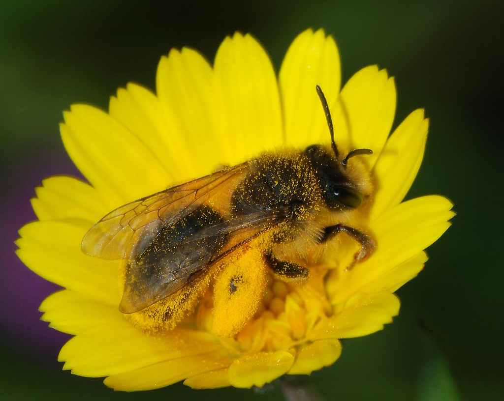

I will begin with an example of a binary generalized linear model using data published by Kuhlman et al. (2021). This study measured bee *Andrena spp.* presence and absence related to flower richness. Surveys were taken from 2015-2016. A total of 51 bees were surveyed and 122 species of flowers were documented.

One goal of this study was to determine whether there was a relationship between flower richness and the presence or absence of bees, in hopes of understanding patterns in the bee community in Logan, Utah.

In my model, flower richness is the predictor variable and bee presence or absence is the response variable. If there is a relationship between the two variables, it would be flower richness affecting bee occurrence, not the presence of bees affecting the richness.

Because there are growing concerns about declining bee populations, another goal would be to find an equation that would predict the probability of a bee population surviving on a landscape with a particular flower richness to help determine which landscapes to introduce bees to.

```r
library(readr)
bees <- read_csv("bee_data.csv")
```

Firstly, I wanted to visualize the data to compare bee presense to flower richness.

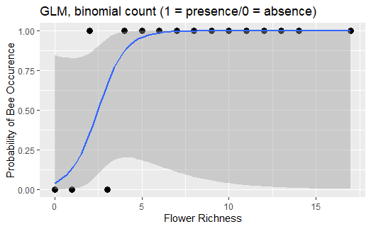

```r
ggplot(bees, aes(Flower_Richness, pres)) +
  geom_point(size=3) +
  geom_smooth(method="glm", method.args=list(family="binomial"(link="logit"))) +
  labs(title="GLM, binomial count (1 = presence/0 = absence)") +
  ylab ("Probability of Bee Occurence") +
  xlab ("Flower Richness")
```

Next, I ran a GLM with presence as the response variable and flower richness as the predictor variable.

```r
model_bees <- glm(pres ~ Flower_Richness, data=bees, family=binomial)
model_bees
```

```
Call:  glm(formula = pres ~ Flower_Richness, family = binomial, data = bees)

Coefficients:
    (Intercept)  Flower_Richness
         -3.149            1.268

Degrees of Freedom: 15 Total (i.e. Null);  14 Residual
Null Deviance:      15.44
Residual Deviance: 4.992    AIC: 8.992
```

Now, I want to check for overdispersion. I used the `arm` package that uses the `binnedplot()` function to offer a graphical approach.

The gray lines in the plot indicate ±2 standard errors, within which approximately 95% of the binned residuals are expected to fall.

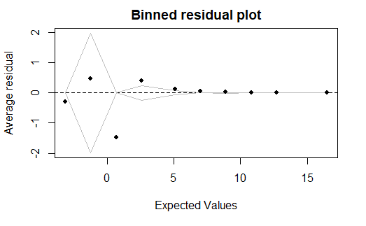

```r
library(arm)
x <- predict(model_bees)
y <- resid(model_bees)
binnedplot(x, y)
```

Next, I ran the model coefficients.

```r
coef(model_bees)
```

```
    (Intercept) Flower_Richness
      -3.149026        1.268050
```

```r
confint(model_bees)
```

```
                      2.5 %    97.5 %
(Intercept)     -11.1985251 0.3286139
Flower_Richness   0.2750862 4.1795590
```

Now I want to interpret the slope of the logistic regression. Dividing the slope coefficient by four will give us an approximate estimate for the maximum predicted effect on the response of a unit change in the predictor. Slope of flower richness variable is 1.3.

In this case, a difference in 1 flower species corresponds to a maximum increase in the probability of occurrence by 32.5% since 1.3/4 = 0.325.

Now, let’s run the model summary to assess significance.

```r
summary(model_bees)
```

```
Call:
glm(formula = pres ~ Flower_Richness, family = binomial, data = bees)

Deviance Residuals:
     Min        1Q    Median        3Q       Max
-1.46521   0.00075   0.00922   0.09839   1.44627

Coefficients:
                Estimate Std. Error z value Pr(>|z|)
(Intercept)      -3.1490     2.4839  -1.268    0.205
Flower_Richness   1.2680     0.8603   1.474    0.141

(Dispersion parameter for binomial family taken to be 1)

    Null deviance: 15.4425  on 15  degrees of freedom
Residual deviance:  4.9918  on 14  degrees of freedom
AIC: 8.9918

Number of Fisher Scoring iterations: 8
```

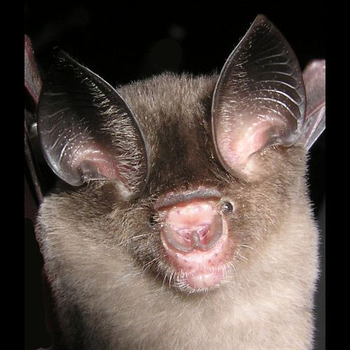

I will now show an example of a generalized linear model using data published by Senawi et al. (2015).

This study examined the correlation between morphological variation and bite force of 35 species of insectivorous bats in Pahang, Malaysia. Bite force was measured by using a bite force transducer setup (pictured below). This device is able to register the force produced by a bat as it bites voluntarily; it converts the pull produced by the bite, applied on a tape-covered metal plate, into an electrical impulse that is read by a force amplifier.

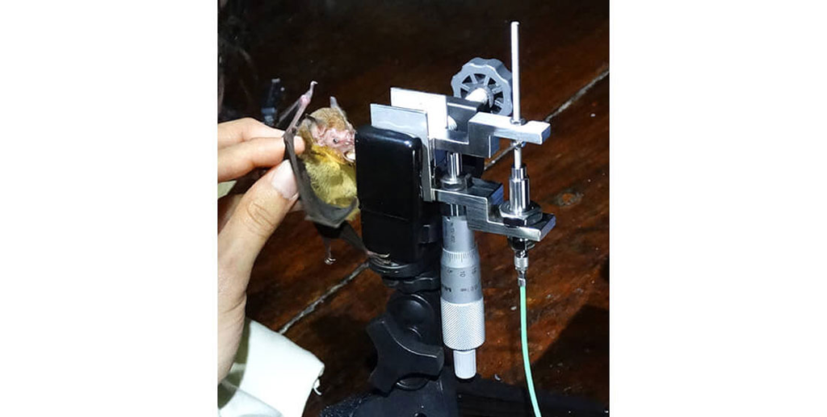

1. Is there a relationship between head length and maximum bite force (Newton) in bats?

```r
library(readr)
library(emmeans)
bats <- read_csv("bite.force.csv")
```

```r
bats.poisson <- glm(MaxBF.N ~ Head.length, family= poisson(link=log), data= bats)
```

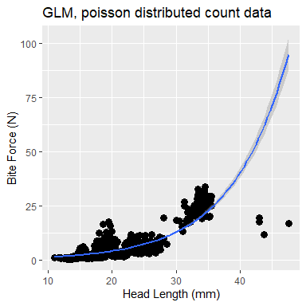

```r
ggplot(bats, aes(Head.length, MaxBF.N)) +
  geom_point(size=3) +
  stat_smooth(method = glm, method.args = list(family = poisson(link =   "log")))+
  labs(title="GLM, poisson distributed count data") +
  xlab ("Head Length (mm)") +
  ylab ("Bite Force (N)")
```

```r
autoplot(bats.poisson)
```

[output not shown]

```r
anova(bats.poisson)
```

```
Analysis of Deviance Table

Model: poisson, link: log

Response: MaxBF.N

Terms added sequentially (first to last)

            Df Deviance Resid. Df Resid. Dev
NULL                          788     4414.7
Head.length  1   3295.5       787     1119.2
```

```r
bats.quasi <- glm(MaxBF.N ~ Head.length, family= quasipoisson, data= bats)
summary(bats.quasi)
```

```
Call:
glm(formula = MaxBF.N ~ Head.length, family = quasipoisson, data = bats)

Deviance Residuals:
    Min       1Q   Median       3Q      Max
-9.8962  -0.9012  -0.3282   0.4959   5.0762

Coefficients:
             Estimate Std. Error t value Pr(>|t|)
(Intercept) -0.857227   0.061421  -13.96   <2e-16 ***
Head.length  0.113916   0.002222   51.27   <2e-16 ***
---
Signif. codes:  0 ‘***’ 0.001 ‘**’ 0.01 ‘*’ 0.05 ‘.’ 0.1 ‘ ’ 1

(Dispersion parameter for quasipoisson family taken to be 1.488115)

    Null deviance: 4414.7  on 788  degrees of freedom
Residual deviance: 1119.2  on 787  degrees of freedom
AIC: NA

Number of Fisher Scoring iterations: 4
```

Now, I graphed the new glm with the quasipoisson.

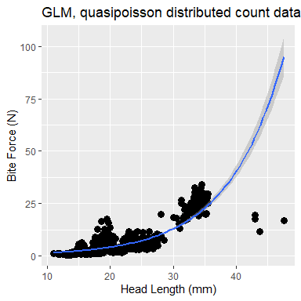

```r
ggplot(bats, aes(Head.length, MaxBF.N)) +
  geom_point(size=3) +
  stat_smooth(method = glm, method.args = list(family = quasipoisson))+
  labs(title="GLM, quasipoisson distributed count data") +
  xlab ("Head Length (mm)") +
  ylab ("Bite Force (N)")
```

For “fun”: What is the expected bite force at 40 (mm) head length?

```r
exp(-0.857227 + 0.113916 * 40)
```

```
[1] 40.42357
```

A bat with a 40 (mm) head length would be expected to have a 40.4 (M) bite force!